# Test

### Minimum requirements

```python
import pandas as pd
```

Let's start first by importing the data

```python
data3 = pd.read_json("C:/Users/mak9a/Documents/data-sample_data-nyctaxi-trips-2011-json_corrigido.json",lines=True)
df11 = pd.DataFrame(data3)
```

```python
df11
```

|  | vendor_id | pickup_datetime | dropoff_datetime | passenger_count | trip_distance | pickup_longitude | pickup_latitude | rate_code | store_and_fwd_flag | dropoff_longitude | dropoff_latitude | payment_type | fare_amount | surcharge | tip_amount | tolls_amount | total_amount |
| --- | --- | --- | --- | --- | --- | --- | --- | --- | --- | --- | --- | --- | --- | --- | --- | --- | --- |
| 0 | CMT | 2011-03-12T06:28:30.352421+00:00 | 2011-03-12T06:36:18.300191+00:00 | 2 | 0.80 | -74.004114 | 40.742950 | NaN | NaN | -73.994712 | 40.747950 | Cash | 5.4 | 0.0 | 0.0 | 0.0 | 5.4 |
| 1 | CMT | 2011-06-30T19:25:12.618256+00:00 | 2011-06-30T19:33:12.03231+00:00 | 1 | 5.40 | -73.996506 | 40.747784 | NaN | NaN | -73.940449 | 40.792385 | Cash | 15.4 | 0.0 | 0.0 | 0.0 | 15.4 |
| 2 | VTS | 2011-08-07T04:03:02.398796+00:00 | 2011-08-07T04:09:58.621034+00:00 | 5 | 1.67 | -73.951340 | 40.752070 | NaN | NaN | -73.944535 | 40.768108 | CASH | 6.1 | 1.0 | 0.0 | 0.0 | 7.1 |
| 3 | VTS | 2011-09-21T23:37:38.878326+00:00 | 2011-09-21T23:52:06.656228+00:00 | 1 | 4.13 | -74.001117 | 40.729128 | NaN | NaN | -73.958122 | 40.721812 | CASH | 12.9 | 0.5 | 0.0 | 0.0 | 13.4 |
| 4 | VTS | 2011-03-30T05:03:23.020477+00:00 | 2011-03-30T05:13:38.282117+00:00 | 1 | 2.03 | -73.976600 | 40.756873 | NaN | NaN | -73.979757 | 40.776075 | CASH | 7.7 | 0.5 | 0.0 | 0.0 | 8.2 |
| ... | ... | ... | ... | ... | ... | ... | ... | ... | ... | ... | ... | ... | ... | ... | ... | ... | ... |
| 999995 | CMT | 2011-04-02T13:15:32.272339+00:00 | 2011-04-02T13:24:19.271276+00:00 | 3 | 6.30 | -73.947063 | 40.784441 | NaN | NaN | -73.987610 | 40.738477 | Cash | 19.4 | 0.0 | 0.0 | 0.0 | 19.4 |
| 999996 | CMT | 2011-10-18T01:35:17.013931+00:00 | 2011-10-18T01:48:22.430122+00:00 | 1 | 1.80 | 0.000000 | 0.000000 | NaN | NaN | 0.000000 | 0.000000 | Cash | 7.4 | 0.0 | 0.0 | 0.0 | 7.4 |
| 999997 | CMT | 2011-07-26T08:06:27.73241+00:00 | 2011-07-26T08:17:27.288263+00:00 | 4 | 2.90 | -74.006156 | 40.743763 | NaN | NaN | -73.974005 | 40.764069 | Cash | 10.6 | 0.0 | 0.0 | 0.0 | 10.6 |
| 999998 | CMT | 2011-02-03T16:00:43.093014+00:00 | 2011-02-03T16:12:52.607878+00:00 | 2 | 1.70 | -73.979615 | 40.783816 | NaN | NaN | -73.988470 | 40.764176 | Credit | 7.4 | 0.0 | 2.0 | 0.0 | 9.4 |
| 999999 | CMT | 2011-11-24T21:27:34.311848+00:00 | 2011-11-24T21:35:35.718069+00:00 | 1 | 2.00 | -73.988829 | 40.731162 | NaN | NaN | -74.009790 | 40.710155 | Cash | 7.8 | 0.0 | 0.0 | 0.0 | 7.8 |

1000000 rows × 17 columns

```python
df11.pickup_datetime.head(6)
```

```
0    2011-03-12T06:28:30.352421+00:00
1    2011-06-30T19:25:12.618256+00:00
2    2011-08-07T04:03:02.398796+00:00
3    2011-09-21T23:37:38.878326+00:00
4    2011-03-30T05:03:23.020477+00:00
5    2011-11-15T18:57:56.343727+00:00
Name: pickup_datetime, dtype: object
```

```python
data4 = pd.read_json("C:/Users/mak9a/Documents/data-sample_data-nyctaxi-trips-2012-json_corrigido.json",lines=True)
df12 = pd.DataFrame(data4)
```

```python
df12
```

|  | vendor_id | pickup_datetime | dropoff_datetime | passenger_count | trip_distance | pickup_longitude | pickup_latitude | rate_code | store_and_fwd_flag | dropoff_longitude | dropoff_latitude | payment_type | fare_amount | surcharge | tip_amount | tolls_amount | total_amount |
| --- | --- | --- | --- | --- | --- | --- | --- | --- | --- | --- | --- | --- | --- | --- | --- | --- | --- |
| 0 | CMT | 2012-06-09T16:21:13.580003+00:00 | 2012-06-09T16:31:19.862787+00:00 | 2 | 0.80 | -74.004114 | 40.742950 | NaN | NaN | -73.994712 | 40.747950 | Cash | 5.4 | 0.0 | 0.0 | 0.0 | 5.4 |
| 1 | CMT | 2012-08-14T21:44:14.940659+00:00 | 2012-08-14T21:54:50.01863+00:00 | 1 | 5.40 | -73.996506 | 40.747784 | NaN | NaN | -73.940449 | 40.792385 | Cash | 15.4 | 0.0 | 0.0 | 0.0 | 15.4 |
| 2 | VTS | 2012-07-06T17:12:07.862531+00:00 | 2012-07-06T17:22:57.404442+00:00 | 5 | 1.67 | -73.951340 | 40.752070 | NaN | NaN | -73.944535 | 40.768108 | CASH | 6.1 | 1.0 | 0.0 | 0.0 | 7.1 |
| 3 | VTS | 2012-07-22T04:12:28.704958+00:00 | 2012-07-22T04:20:45.142945+00:00 | 1 | 4.13 | -74.001117 | 40.729128 | NaN | NaN | -73.958122 | 40.721812 | CASH | 12.9 | 0.5 | 0.0 | 0.0 | 13.4 |
| 4 | VTS | 2012-07-11T11:40:13.77461+00:00 | 2012-07-11T11:49:03.034108+00:00 | 1 | 2.03 | -73.976600 | 40.756873 | NaN | NaN | -73.979757 | 40.776075 | CASH | 7.7 | 0.5 | 0.0 | 0.0 | 8.2 |
| ... | ... | ... | ... | ... | ... | ... | ... | ... | ... | ... | ... | ... | ... | ... | ... | ... | ... |
| 999995 | CMT | 2012-07-02T02:16:07.72331+00:00 | 2012-07-02T02:24:36.05472+00:00 | 3 | 6.30 | -73.947063 | 40.784441 | NaN | NaN | -73.987610 | 40.738477 | Cash | 19.4 | 0.0 | 0.0 | 0.0 | 19.4 |
| 999996 | CMT | 2012-04-11T16:24:49.255035+00:00 | 2012-04-11T16:30:46.179091+00:00 | 1 | 1.80 | 0.000000 | 0.000000 | NaN | NaN | 0.000000 | 0.000000 | Cash | 7.4 | 0.0 | 0.0 | 0.0 | 7.4 |
| 999997 | CMT | 2012-09-15T15:00:58.80813+00:00 | 2012-09-15T15:08:10.313917+00:00 | 4 | 2.90 | -74.006156 | 40.743763 | NaN | NaN | -73.974005 | 40.764069 | Cash | 10.6 | 0.0 | 0.0 | 0.0 | 10.6 |
| 999998 | CMT | 2012-06-25T09:17:36.81712+00:00 | 2012-06-25T09:31:07.322351+00:00 | 2 | 1.70 | -73.979615 | 40.783816 | NaN | NaN | -73.988470 | 40.764176 | Credit | 7.4 | 0.0 | 2.0 | 0.0 | 9.4 |
| 999999 | CMT | 2012-08-24T07:25:13.503063+00:00 | 2012-08-24T07:38:33.870016+00:00 | 1 | 2.00 | -73.988829 | 40.731162 | NaN | NaN | -74.009790 | 40.710155 | Cash | 7.8 | 0.0 | 0.0 | 0.0 | 7.8 |

1000000 rows × 17 columns

```python
data2 = pd.read_json("C:/Users/mak9a/Documents/data-sample_data-nyctaxi-trips-2010-json_corrigido.json",lines=True)
df10 = pd.DataFrame(data2)
```

```python
df10
```

|  | vendor_id | pickup_datetime | dropoff_datetime | passenger_count | trip_distance | pickup_longitude | pickup_latitude | rate_code | store_and_fwd_flag | dropoff_longitude | dropoff_latitude | payment_type | fare_amount | surcharge | tip_amount | tolls_amount | total_amount |
| --- | --- | --- | --- | --- | --- | --- | --- | --- | --- | --- | --- | --- | --- | --- | --- | --- | --- |
| 0 | CMT | 2010-11-17T00:21:17.506247+00:00 | 2010-11-17T00:30:28.841338+00:00 | 2 | 0.80 | -74.004114 | 40.742950 | NaN | NaN | -73.994712 | 40.747950 | Cash | 5.4 | 0.0 | 0.0 | 0.0 | 5.4 |
| 1 | CMT | 2010-10-10T16:59:14.80046+00:00 | 2010-10-10T17:10:15.067626+00:00 | 1 | 5.40 | -73.996506 | 40.747784 | NaN | NaN | -73.940449 | 40.792385 | Cash | 15.4 | 0.0 | 0.0 | 0.0 | 15.4 |
| 2 | VTS | 2010-09-09T21:04:07.684032+00:00 | 2010-09-09T21:09:05.556974+00:00 | 5 | 1.67 | -73.951340 | 40.752070 | NaN | NaN | -73.944535 | 40.768108 | CASH | 6.1 | 1.0 | 0.0 | 0.0 | 7.1 |
| 3 | VTS | 2010-10-28T05:13:20.92518+00:00 | 2010-10-28T05:18:47.370679+00:00 | 1 | 4.13 | -74.001117 | 40.729128 | NaN | NaN | -73.958122 | 40.721812 | CASH | 12.9 | 0.5 | 0.0 | 0.0 | 13.4 |
| 4 | VTS | 2010-10-26T11:42:00.271397+00:00 | 2010-10-26T11:49:58.905808+00:00 | 1 | 2.03 | -73.976600 | 40.756873 | NaN | NaN | -73.979757 | 40.776075 | CASH | 7.7 | 0.5 | 0.0 | 0.0 | 8.2 |
| ... | ... | ... | ... | ... | ... | ... | ... | ... | ... | ... | ... | ... | ... | ... | ... | ... | ... |
| 999995 | CMT | 2010-09-11T06:53:47.121019+00:00 | 2010-09-11T06:57:00.35865+00:00 | 3 | 6.30 | -73.947063 | 40.784441 | NaN | NaN | -73.987610 | 40.738477 | Cash | 19.4 | 0.0 | 0.0 | 0.0 | 19.4 |
| 999996 | CMT | 2010-08-29T01:05:55.3188+00:00 | 2010-08-29T01:15:34.127238+00:00 | 1 | 1.80 | 0.000000 | 0.000000 | NaN | NaN | 0.000000 | 0.000000 | Cash | 7.4 | 0.0 | 0.0 | 0.0 | 7.4 |
| 999997 | CMT | 2010-02-11T23:36:53.8284+00:00 | 2010-02-11T23:47:42.151155+00:00 | 4 | 2.90 | -74.006156 | 40.743763 | NaN | NaN | -73.974005 | 40.764069 | Cash | 10.6 | 0.0 | 0.0 | 0.0 | 10.6 |
| 999998 | CMT | 2010-07-16T06:23:47.24255+00:00 | 2010-07-16T06:32:22.328008+00:00 | 2 | 1.70 | -73.979615 | 40.783816 | NaN | NaN | -73.988470 | 40.764176 | Credit | 7.4 | 0.0 | 2.0 | 0.0 | 9.4 |
| 999999 | CMT | 2010-01-13T23:59:45.778874+00:00 | 2010-01-14T00:03:50.775013+00:00 | 1 | 2.00 | -73.988829 | 40.731162 | NaN | NaN | -74.009790 | 40.710155 | Cash | 7.8 | 0.0 | 0.0 | 0.0 | 7.8 |

1000000 rows × 17 columns

```python
data1 = pd.read_json("C:/Users/mak9a/Documents/data-sample_data-nyctaxi-trips-2009-json_corrigido.json",lines=True)
df09 = pd.DataFrame(data1)
```

```python
df09
```

|  | vendor_id | pickup_datetime | dropoff_datetime | passenger_count | trip_distance | pickup_longitude | pickup_latitude | rate_code | store_and_fwd_flag | dropoff_longitude | dropoff_latitude | payment_type | fare_amount | surcharge | tip_amount | tolls_amount | total_amount |
| --- | --- | --- | --- | --- | --- | --- | --- | --- | --- | --- | --- | --- | --- | --- | --- | --- | --- |
| 0 | CMT | 2009-04-21T18:51:11.767205+00:00 | 2009-04-21T18:57:09.433767+00:00 | 2 | 0.80 | -74.004114 | 40.742950 | NaN | NaN | -73.994712 | 40.747950 | Cash | 5.4 | 0.0 | 0.0 | 0.0 | 5.4 |
| 1 | CMT | 2009-01-13T07:40:07.639754+00:00 | 2009-01-13T07:50:36.386011+00:00 | 1 | 5.40 | -73.996506 | 40.747784 | NaN | NaN | -73.940449 | 40.792385 | Cash | 15.4 | 0.0 | 0.0 | 0.0 | 15.4 |
| 2 | VTS | 2009-01-06T19:30:44.142187+00:00 | 2009-01-06T19:43:09.908429+00:00 | 5 | 1.67 | -73.951340 | 40.752070 | NaN | NaN | -73.944535 | 40.768108 | CASH | 6.1 | 1.0 | 0.0 | 0.0 | 7.1 |
| 3 | VTS | 2009-09-24T08:28:09.004451+00:00 | 2009-09-24T08:41:56.739991+00:00 | 1 | 4.13 | -74.001117 | 40.729128 | NaN | NaN | -73.958122 | 40.721812 | CASH | 12.9 | 0.5 | 0.0 | 0.0 | 13.4 |
| 4 | VTS | 2009-10-29T05:50:39.214629+00:00 | 2009-10-29T05:57:22.880174+00:00 | 1 | 2.03 | -73.976600 | 40.756873 | NaN | NaN | -73.979757 | 40.776075 | CASH | 7.7 | 0.5 | 0.0 | 0.0 | 8.2 |
| ... | ... | ... | ... | ... | ... | ... | ... | ... | ... | ... | ... | ... | ... | ... | ... | ... | ... |
| 999995 | CMT | 2009-04-24T20:26:49.177887+00:00 | 2009-04-24T20:30:19.625874+00:00 | 3 | 6.30 | -73.947063 | 40.784441 | NaN | NaN | -73.987610 | 40.738477 | Cash | 19.4 | 0.0 | 0.0 | 0.0 | 19.4 |
| 999996 | CMT | 2009-10-15T23:50:58.953649+00:00 | 2009-10-16T00:04:56.874141+00:00 | 1 | 1.80 | 0.000000 | 0.000000 | NaN | NaN | 0.000000 | 0.000000 | Cash | 7.4 | 0.0 | 0.0 | 0.0 | 7.4 |
| 999997 | CMT | 2009-10-17T23:32:59.567188+00:00 | 2009-10-17T23:43:25.383257+00:00 | 4 | 2.90 | -74.006156 | 40.743763 | NaN | NaN | -73.974005 | 40.764069 | Cash | 10.6 | 0.0 | 0.0 | 0.0 | 10.6 |
| 999998 | CMT | 2009-04-29T16:24:48.679701+00:00 | 2009-04-29T16:36:45.81748+00:00 | 2 | 1.70 | -73.979615 | 40.783816 | NaN | NaN | -73.988470 | 40.764176 | Credit | 7.4 | 0.0 | 2.0 | 0.0 | 9.4 |
| 999999 | CMT | 2009-02-27T21:56:18.386664+00:00 | 2009-02-27T22:09:06.009187+00:00 | 1 | 2.00 | -73.988829 | 40.731162 | NaN | NaN | -74.009790 | 40.710155 | Cash | 7.8 | 0.0 | 0.0 | 0.0 | 7.8 |

1000000 rows × 17 columns

```python
frames=[df09,df10,df11,df12]
df=pd.concat(frames, axis=0, join='outer', ignore_index=False, keys=None,
          levels=None, names=None, verify_integrity=False, copy=True)
df
```

|  | vendor_id | pickup_datetime | dropoff_datetime | passenger_count | trip_distance | pickup_longitude | pickup_latitude | rate_code | store_and_fwd_flag | dropoff_longitude | dropoff_latitude | payment_type | fare_amount | surcharge | tip_amount | tolls_amount | total_amount |
| --- | --- | --- | --- | --- | --- | --- | --- | --- | --- | --- | --- | --- | --- | --- | --- | --- | --- |
| 0 | CMT | 2009-04-21T18:51:11.767205+00:00 | 2009-04-21T18:57:09.433767+00:00 | 2 | 0.80 | -74.004114 | 40.742950 | NaN | NaN | -73.994712 | 40.747950 | Cash | 5.4 | 0.0 | 0.0 | 0.0 | 5.4 |
| 1 | CMT | 2009-01-13T07:40:07.639754+00:00 | 2009-01-13T07:50:36.386011+00:00 | 1 | 5.40 | -73.996506 | 40.747784 | NaN | NaN | -73.940449 | 40.792385 | Cash | 15.4 | 0.0 | 0.0 | 0.0 | 15.4 |
| 2 | VTS | 2009-01-06T19:30:44.142187+00:00 | 2009-01-06T19:43:09.908429+00:00 | 5 | 1.67 | -73.951340 | 40.752070 | NaN | NaN | -73.944535 | 40.768108 | CASH | 6.1 | 1.0 | 0.0 | 0.0 | 7.1 |
| 3 | VTS | 2009-09-24T08:28:09.004451+00:00 | 2009-09-24T08:41:56.739991+00:00 | 1 | 4.13 | -74.001117 | 40.729128 | NaN | NaN | -73.958122 | 40.721812 | CASH | 12.9 | 0.5 | 0.0 | 0.0 | 13.4 |
| 4 | VTS | 2009-10-29T05:50:39.214629+00:00 | 2009-10-29T05:57:22.880174+00:00 | 1 | 2.03 | -73.976600 | 40.756873 | NaN | NaN | -73.979757 | 40.776075 | CASH | 7.7 | 0.5 | 0.0 | 0.0 | 8.2 |
| ... | ... | ... | ... | ... | ... | ... | ... | ... | ... | ... | ... | ... | ... | ... | ... | ... | ... |
| 999995 | CMT | 2012-07-02T02:16:07.72331+00:00 | 2012-07-02T02:24:36.05472+00:00 | 3 | 6.30 | -73.947063 | 40.784441 | NaN | NaN | -73.987610 | 40.738477 | Cash | 19.4 | 0.0 | 0.0 | 0.0 | 19.4 |
| 999996 | CMT | 2012-04-11T16:24:49.255035+00:00 | 2012-04-11T16:30:46.179091+00:00 | 1 | 1.80 | 0.000000 | 0.000000 | NaN | NaN | 0.000000 | 0.000000 | Cash | 7.4 | 0.0 | 0.0 | 0.0 | 7.4 |
| 999997 | CMT | 2012-09-15T15:00:58.80813+00:00 | 2012-09-15T15:08:10.313917+00:00 | 4 | 2.90 | -74.006156 | 40.743763 | NaN | NaN | -73.974005 | 40.764069 | Cash | 10.6 | 0.0 | 0.0 | 0.0 | 10.6 |
| 999998 | CMT | 2012-06-25T09:17:36.81712+00:00 | 2012-06-25T09:31:07.322351+00:00 | 2 | 1.70 | -73.979615 | 40.783816 | NaN | NaN | -73.988470 | 40.764176 | Credit | 7.4 | 0.0 | 2.0 | 0.0 | 9.4 |
| 999999 | CMT | 2012-08-24T07:25:13.503063+00:00 | 2012-08-24T07:38:33.870016+00:00 | 1 | 2.00 | -73.988829 | 40.731162 | NaN | NaN | -74.009790 | 40.710155 | Cash | 7.8 | 0.0 | 0.0 | 0.0 | 7.8 |

4000000 rows × 17 columns

```python
df.columns
```

```
Index(['vendor_id', 'pickup_datetime', 'dropoff_datetime', 'passenger_count',
       'trip_distance', 'pickup_longitude', 'pickup_latitude', 'rate_code',
       'store_and_fwd_flag', 'dropoff_longitude', 'dropoff_latitude',
       'payment_type', 'fare_amount', 'surcharge', 'tip_amount',
       'tolls_amount', 'total_amount'],
      dtype='object')
```

```python
from pandasql import sqldf
pysqldf = lambda q: sqldf(q, globals())
```

### What is the average distance traveled by trips with a maximum of 2 passengers

```python
q='''SELECT AVG(trip_distance) AS AVG_trip_distance
    FROM df
    WHERE (passenger_count=2) OR (passenger_count=1)
    ;'''
```

```python
avg=pysqldf(q)
```

```python
avg
```

|  | AVG_trip_distance |
| --- | --- |
| 0 | 2.662629 |

The average distance traveled by trips with a maximum of 2 passengers is 2.662629.

### Which are the 3 biggest vendors based on the total amount of money raised

```python
q='''SELECT vendor_id, SUM(total_amount) AS TT_money
    FROM df
     GROUP BY vendor_id
     ORDER BY TT_money
    ;'''
```

```python
bigvendor=pysqldf(q)
```

```python
bigvendor.tail(3)
```

|  | vendor_id | TT_money |
| --- | --- | --- |
| 1 | DDS | 2.714902e+06 |
| 2 | VTS | 1.904343e+07 |
| 3 | CMT | 1.954908e+07 |

The 3 biggest vendors based on the total amount of money raised are Creative Mobile Technologies. LLC, VeriFone Inc and Dependable Driver Service. Inc.

```python
dfCopy=df.copy()
```

As we see the output of pickup_datetime 2009-04-21**T**18:51:11.767205+00:00, we have a **T** between the date and the time That's why, we had the idea of replace it by a space or split the date and the time. we created a copy of the dataframe in case we messed up.

```python
new = dfCopy["pickup_datetime"].str.split("T", n = 1, expand = True)
```

```python
dfCopy["Date"]= new[0]

dfCopy["Time"]= new[1]
```

```python
dfCopy
```

|  | vendor_id | pickup_datetime | dropoff_datetime | passenger_count | trip_distance | pickup_longitude | pickup_latitude | rate_code | store_and_fwd_flag | dropoff_longitude | dropoff_latitude | payment_type | fare_amount | surcharge | tip_amount | tolls_amount | total_amount | Date | Time |
| --- | --- | --- | --- | --- | --- | --- | --- | --- | --- | --- | --- | --- | --- | --- | --- | --- | --- | --- | --- |
| 0 | CMT | 2009-04-21T18:51:11.767205+00:00 | 2009-04-21T18:57:09.433767+00:00 | 2 | 0.80 | -74.004114 | 40.742950 | NaN | NaN | -73.994712 | 40.747950 | Cash | 5.4 | 0.0 | 0.0 | 0.0 | 5.4 | 2009-04-21 | 18:51:11.767205+00:00 |
| 1 | CMT | 2009-01-13T07:40:07.639754+00:00 | 2009-01-13T07:50:36.386011+00:00 | 1 | 5.40 | -73.996506 | 40.747784 | NaN | NaN | -73.940449 | 40.792385 | Cash | 15.4 | 0.0 | 0.0 | 0.0 | 15.4 | 2009-01-13 | 07:40:07.639754+00:00 |
| 2 | VTS | 2009-01-06T19:30:44.142187+00:00 | 2009-01-06T19:43:09.908429+00:00 | 5 | 1.67 | -73.951340 | 40.752070 | NaN | NaN | -73.944535 | 40.768108 | CASH | 6.1 | 1.0 | 0.0 | 0.0 | 7.1 | 2009-01-06 | 19:30:44.142187+00:00 |
| 3 | VTS | 2009-09-24T08:28:09.004451+00:00 | 2009-09-24T08:41:56.739991+00:00 | 1 | 4.13 | -74.001117 | 40.729128 | NaN | NaN | -73.958122 | 40.721812 | CASH | 12.9 | 0.5 | 0.0 | 0.0 | 13.4 | 2009-09-24 | 08:28:09.004451+00:00 |
| 4 | VTS | 2009-10-29T05:50:39.214629+00:00 | 2009-10-29T05:57:22.880174+00:00 | 1 | 2.03 | -73.976600 | 40.756873 | NaN | NaN | -73.979757 | 40.776075 | CASH | 7.7 | 0.5 | 0.0 | 0.0 | 8.2 | 2009-10-29 | 05:50:39.214629+00:00 |
| ... | ... | ... | ... | ... | ... | ... | ... | ... | ... | ... | ... | ... | ... | ... | ... | ... | ... | ... | ... |
| 999995 | CMT | 2012-07-02T02:16:07.72331+00:00 | 2012-07-02T02:24:36.05472+00:00 | 3 | 6.30 | -73.947063 | 40.784441 | NaN | NaN | -73.987610 | 40.738477 | Cash | 19.4 | 0.0 | 0.0 | 0.0 | 19.4 | 2012-07-02 | 02:16:07.72331+00:00 |
| 999996 | CMT | 2012-04-11T16:24:49.255035+00:00 | 2012-04-11T16:30:46.179091+00:00 | 1 | 1.80 | 0.000000 | 0.000000 | NaN | NaN | 0.000000 | 0.000000 | Cash | 7.4 | 0.0 | 0.0 | 0.0 | 7.4 | 2012-04-11 | 16:24:49.255035+00:00 |
| 999997 | CMT | 2012-09-15T15:00:58.80813+00:00 | 2012-09-15T15:08:10.313917+00:00 | 4 | 2.90 | -74.006156 | 40.743763 | NaN | NaN | -73.974005 | 40.764069 | Cash | 10.6 | 0.0 | 0.0 | 0.0 | 10.6 | 2012-09-15 | 15:00:58.80813+00:00 |
| 999998 | CMT | 2012-06-25T09:17:36.81712+00:00 | 2012-06-25T09:31:07.322351+00:00 | 2 | 1.70 | -73.979615 | 40.783816 | NaN | NaN | -73.988470 | 40.764176 | Credit | 7.4 | 0.0 | 2.0 | 0.0 | 9.4 | 2012-06-25 | 09:17:36.81712+00:00 |
| 999999 | CMT | 2012-08-24T07:25:13.503063+00:00 | 2012-08-24T07:38:33.870016+00:00 | 1 | 2.00 | -73.988829 | 40.731162 | NaN | NaN | -74.009790 | 40.710155 | Cash | 7.8 | 0.0 | 0.0 | 0.0 | 7.8 | 2012-08-24 | 07:25:13.503063+00:00 |

4000000 rows × 19 columns

```python
new1 = dfCopy["Date"].str.split("-", n = 2, expand = True)
```

```python
new1
```

|  | 0 | 1 | 2 |
| --- | --- | --- | --- |
| 0 | 2009 | 04 | 21 |
| 1 | 2009 | 01 | 13 |
| 2 | 2009 | 01 | 06 |
| 3 | 2009 | 09 | 24 |
| 4 | 2009 | 10 | 29 |
| ... | ... | ... | ... |
| 999995 | 2012 | 07 | 02 |
| 999996 | 2012 | 04 | 11 |
| 999997 | 2012 | 09 | 15 |
| 999998 | 2012 | 06 | 25 |
| 999999 | 2012 | 08 | 24 |

4000000 rows × 3 columns

```python
dfCopy["Year"]= new1[0]
dfCopy["Month"]= new1[1]
dfCopy["Day"]= new1[2]
```

```python
dfCopy.columns
```

```
Index(['vendor_id', 'pickup_datetime', 'dropoff_datetime', 'passenger_count',
       'trip_distance', 'pickup_longitude', 'pickup_latitude', 'rate_code',
       'store_and_fwd_flag', 'dropoff_longitude', 'dropoff_latitude',
       'payment_type', 'fare_amount', 'surcharge', 'tip_amount',
       'tolls_amount', 'total_amount', 'Date', 'Time', 'Year', 'Month', 'Day'],
      dtype='object')
```

Let's select the rides paid with cash first

```python
q='''
    SELECT Month, SUM(total_amount) AS TT_amount
    FROM dfCopy
    GROUP BY Month
    HAVING payment_type='Cas' OR payment_type='CAS' OR payment_type='Cash' OR payment_type='CASH' OR payment_type='CSH'
'''
```

```python
ridesPerMonth=pysqldf(q)
```

```python
ridesPerMonth
```

|  | Month | TT_amount |
| --- | --- | --- |
| 0 | 01 | 3424548.89 |
| 1 | 02 | 3602831.58 |
| 2 | 03 | 3948317.61 |
| 3 | 04 | 3815963.10 |
| 4 | 05 | 3946890.86 |
| 5 | 06 | 3814268.22 |
| 6 | 07 | 3952167.32 |
| 7 | 08 | 3951844.76 |
| 8 | 09 | 3813661.74 |
| 9 | 10 | 3816195.23 |
| 10 | 11 | 2618854.71 |
| 11 | 12 | 601921.58 |

### Make a histogram of the monthly distribution over 4 years of rides paid with cash

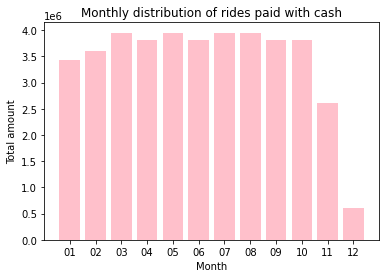

```python
import numpy as np
import matplotlib.pyplot as plt

plt.bar(ridesPerMonth.Month, ridesPerMonth.TT_amount, align='center', color='pink')
plt.ylabel('Total amount')
plt.xlabel('Month')
plt.title('Monthly distribution of rides paid with cash')
plt.show()
```

### Make a time series chart computing the number of tips each day for the last 3 months of 2012

Let's start by copying the df12. then we will replace **T** in pickup_datetime by space so that we can convert it to time series later.

```python
df12Copy=df12.copy()
df12Copy
```

|  | vendor_id | pickup_datetime | dropoff_datetime | passenger_count | trip_distance | pickup_longitude | pickup_latitude | rate_code | store_and_fwd_flag | dropoff_longitude | dropoff_latitude | payment_type | fare_amount | surcharge | tip_amount | tolls_amount | total_amount |
| --- | --- | --- | --- | --- | --- | --- | --- | --- | --- | --- | --- | --- | --- | --- | --- | --- | --- |
| 0 | CMT | 2012-06-09T16:21:13.580003+00:00 | 2012-06-09T16:31:19.862787+00:00 | 2 | 0.80 | -74.004114 | 40.742950 | NaN | NaN | -73.994712 | 40.747950 | Cash | 5.4 | 0.0 | 0.0 | 0.0 | 5.4 |
| 1 | CMT | 2012-08-14T21:44:14.940659+00:00 | 2012-08-14T21:54:50.01863+00:00 | 1 | 5.40 | -73.996506 | 40.747784 | NaN | NaN | -73.940449 | 40.792385 | Cash | 15.4 | 0.0 | 0.0 | 0.0 | 15.4 |
| 2 | VTS | 2012-07-06T17:12:07.862531+00:00 | 2012-07-06T17:22:57.404442+00:00 | 5 | 1.67 | -73.951340 | 40.752070 | NaN | NaN | -73.944535 | 40.768108 | CASH | 6.1 | 1.0 | 0.0 | 0.0 | 7.1 |
| 3 | VTS | 2012-07-22T04:12:28.704958+00:00 | 2012-07-22T04:20:45.142945+00:00 | 1 | 4.13 | -74.001117 | 40.729128 | NaN | NaN | -73.958122 | 40.721812 | CASH | 12.9 | 0.5 | 0.0 | 0.0 | 13.4 |
| 4 | VTS | 2012-07-11T11:40:13.77461+00:00 | 2012-07-11T11:49:03.034108+00:00 | 1 | 2.03 | -73.976600 | 40.756873 | NaN | NaN | -73.979757 | 40.776075 | CASH | 7.7 | 0.5 | 0.0 | 0.0 | 8.2 |
| ... | ... | ... | ... | ... | ... | ... | ... | ... | ... | ... | ... | ... | ... | ... | ... | ... | ... |
| 999995 | CMT | 2012-07-02T02:16:07.72331+00:00 | 2012-07-02T02:24:36.05472+00:00 | 3 | 6.30 | -73.947063 | 40.784441 | NaN | NaN | -73.987610 | 40.738477 | Cash | 19.4 | 0.0 | 0.0 | 0.0 | 19.4 |
| 999996 | CMT | 2012-04-11T16:24:49.255035+00:00 | 2012-04-11T16:30:46.179091+00:00 | 1 | 1.80 | 0.000000 | 0.000000 | NaN | NaN | 0.000000 | 0.000000 | Cash | 7.4 | 0.0 | 0.0 | 0.0 | 7.4 |
| 999997 | CMT | 2012-09-15T15:00:58.80813+00:00 | 2012-09-15T15:08:10.313917+00:00 | 4 | 2.90 | -74.006156 | 40.743763 | NaN | NaN | -73.974005 | 40.764069 | Cash | 10.6 | 0.0 | 0.0 | 0.0 | 10.6 |
| 999998 | CMT | 2012-06-25T09:17:36.81712+00:00 | 2012-06-25T09:31:07.322351+00:00 | 2 | 1.70 | -73.979615 | 40.783816 | NaN | NaN | -73.988470 | 40.764176 | Credit | 7.4 | 0.0 | 2.0 | 0.0 | 9.4 |
| 999999 | CMT | 2012-08-24T07:25:13.503063+00:00 | 2012-08-24T07:38:33.870016+00:00 | 1 | 2.00 | -73.988829 | 40.731162 | NaN | NaN | -74.009790 | 40.710155 | Cash | 7.8 | 0.0 | 0.0 | 0.0 | 7.8 |

1000000 rows × 17 columns

```python
df12Copy['pickup_datetime']=df12Copy['pickup_datetime'].replace(['T'],' ',regex=True)
df12Copy['dropoff_datetime']=df12Copy['dropoff_datetime'].replace(['T'],' ',regex=True)
```

```python
df12Copy['pickup_datetime']
```

```
0         2012-06-09 16:21:13.580003+00:00
1         2012-08-14 21:44:14.940659+00:00
2         2012-07-06 17:12:07.862531+00:00
3         2012-07-22 04:12:28.704958+00:00
4          2012-07-11 11:40:13.77461+00:00
                        ...
999995     2012-07-02 02:16:07.72331+00:00
999996    2012-04-11 16:24:49.255035+00:00
999997     2012-09-15 15:00:58.80813+00:00
999998     2012-06-25 09:17:36.81712+00:00
999999    2012-08-24 07:25:13.503063+00:00
Name: pickup_datetime, Length: 1000000, dtype: object
```

```python
df12Copy.index = pd.to_datetime(df12Copy.pickup_datetime)
```

```python
df12Copy
```

| pickup_datetime | vendor_id | pickup_datetime | dropoff_datetime | passenger_count | trip_distance | pickup_longitude | pickup_latitude | rate_code | store_and_fwd_flag | dropoff_longitude | dropoff_latitude | payment_type | fare_amount | surcharge | tip_amount | tolls_amount | total_amount |
| --- | --- | --- | --- | --- | --- | --- | --- | --- | --- | --- | --- | --- | --- | --- | --- | --- | --- |
| 2012-06-09 16:21:13.580003+00:00 | CMT | 2012-06-09 16:21:13.580003+00:00 | 2012-06-09 16:31:19.862787+00:00 | 2 | 0.80 | -74.004114 | 40.742950 | NaN | NaN | -73.994712 | 40.747950 | Cash | 5.4 | 0.0 | 0.0 | 0.0 | 5.4 |
| 2012-08-14 21:44:14.940659+00:00 | CMT | 2012-08-14 21:44:14.940659+00:00 | 2012-08-14 21:54:50.01863+00:00 | 1 | 5.40 | -73.996506 | 40.747784 | NaN | NaN | -73.940449 | 40.792385 | Cash | 15.4 | 0.0 | 0.0 | 0.0 | 15.4 |
| 2012-07-06 17:12:07.862531+00:00 | VTS | 2012-07-06 17:12:07.862531+00:00 | 2012-07-06 17:22:57.404442+00:00 | 5 | 1.67 | -73.951340 | 40.752070 | NaN | NaN | -73.944535 | 40.768108 | CASH | 6.1 | 1.0 | 0.0 | 0.0 | 7.1 |
| 2012-07-22 04:12:28.704958+00:00 | VTS | 2012-07-22 04:12:28.704958+00:00 | 2012-07-22 04:20:45.142945+00:00 | 1 | 4.13 | -74.001117 | 40.729128 | NaN | NaN | -73.958122 | 40.721812 | CASH | 12.9 | 0.5 | 0.0 | 0.0 | 13.4 |
| 2012-07-11 11:40:13.774610+00:00 | VTS | 2012-07-11 11:40:13.77461+00:00 | 2012-07-11 11:49:03.034108+00:00 | 1 | 2.03 | -73.976600 | 40.756873 | NaN | NaN | -73.979757 | 40.776075 | CASH | 7.7 | 0.5 | 0.0 | 0.0 | 8.2 |
| ... | ... | ... | ... | ... | ... | ... | ... | ... | ... | ... | ... | ... | ... | ... | ... | ... | ... |
| 2012-07-02 02:16:07.723310+00:00 | CMT | 2012-07-02 02:16:07.72331+00:00 | 2012-07-02 02:24:36.05472+00:00 | 3 | 6.30 | -73.947063 | 40.784441 | NaN | NaN | -73.987610 | 40.738477 | Cash | 19.4 | 0.0 | 0.0 | 0.0 | 19.4 |
| 2012-04-11 16:24:49.255035+00:00 | CMT | 2012-04-11 16:24:49.255035+00:00 | 2012-04-11 16:30:46.179091+00:00 | 1 | 1.80 | 0.000000 | 0.000000 | NaN | NaN | 0.000000 | 0.000000 | Cash | 7.4 | 0.0 | 0.0 | 0.0 | 7.4 |
| 2012-09-15 15:00:58.808130+00:00 | CMT | 2012-09-15 15:00:58.80813+00:00 | 2012-09-15 15:08:10.313917+00:00 | 4 | 2.90 | -74.006156 | 40.743763 | NaN | NaN | -73.974005 | 40.764069 | Cash | 10.6 | 0.0 | 0.0 | 0.0 | 10.6 |
| 2012-06-25 09:17:36.817120+00:00 | CMT | 2012-06-25 09:17:36.81712+00:00 | 2012-06-25 09:31:07.322351+00:00 | 2 | 1.70 | -73.979615 | 40.783816 | NaN | NaN | -73.988470 | 40.764176 | Credit | 7.4 | 0.0 | 2.0 | 0.0 | 9.4 |
| 2012-08-24 07:25:13.503063+00:00 | CMT | 2012-08-24 07:25:13.503063+00:00 | 2012-08-24 07:38:33.870016+00:00 | 1 | 2.00 | -73.988829 | 40.731162 | NaN | NaN | -74.009790 | 40.710155 | Cash | 7.8 | 0.0 | 0.0 | 0.0 | 7.8 |

1000000 rows × 17 columns

```python
df12Copy.describe()
```

|  | passenger_count | trip_distance | pickup_longitude | pickup_latitude | rate_code | store_and_fwd_flag | dropoff_longitude | dropoff_latitude | fare_amount | surcharge | tip_amount | tolls_amount | total_amount |
| --- | --- | --- | --- | --- | --- | --- | --- | --- | --- | --- | --- | --- | --- |
| count | 1000000.000000 | 1000000.000000 | 1000000.000000 | 1000000.000000 | 0.0 | 62.0 | 1000000.000000 | 1000000.000000 | 1000000.000000 | 1000000.000000 | 1000000.000000 | 1000000.000000 | 1000000.000000 |
| mean | 1.733573 | 2.678209 | -72.830595 | 40.124727 | NaN | 0.0 | -72.848044 | 40.134998 | 9.629421 | 0.161939 | 0.408540 | 0.123594 | 10.326866 |
| std | 1.254536 | 3.130602 | 9.122398 | 5.026364 | NaN | 0.0 | 9.050547 | 4.986515 | 7.567481 | 0.308355 | 1.258633 | 0.761664 | 8.503211 |
| min | 0.000000 | 0.000000 | -84.878351 | -0.009262 | NaN | 0.0 | -79.191394 | -0.015202 | 2.500000 | 0.000000 | 0.000000 | 0.000000 | 2.500000 |
| 25% | 1.000000 | 1.000000 | -73.991124 | 40.736387 | NaN | 0.0 | -73.990665 | 40.735366 | 5.400000 | 0.000000 | 0.000000 | 0.000000 | 5.700000 |
| 50% | 1.000000 | 1.700000 | -73.981110 | 40.754531 | NaN | 0.0 | -73.979534 | 40.754488 | 7.300000 | 0.000000 | 0.000000 | 0.000000 | 7.800000 |
| 75% | 2.000000 | 3.000000 | -73.966815 | 40.768442 | NaN | 0.0 | -73.963385 | 40.769523 | 10.900000 | 0.000000 | 0.000000 | 0.000000 | 11.400000 |
| max | 6.000000 | 49.920000 | 0.004023 | 47.922847 | NaN | 0.0 | 0.008668 | 47.935812 | 200.000000 | 1.000000 | 98.230000 | 20.000000 | 230.000000 |

Let's check the last date in the dataframe

```python
print(df12Copy.index.max())
```

```
2012-10-27 23:59:05.262820+00:00
```

```python
OCT=df12Copy[df12Copy.index.month == 10]
NOV=df12Copy[df12Copy.index.month == 9]
AUG=df12Copy[df12Copy.index.month == 8]
L3MON=pd.concat([OCT,NOV,AUG], axis=0, join='outer', ignore_index=False, keys=None,
          levels=None, names=None, verify_integrity=False, copy=True)
L3MON
```

| pickup_datetime | vendor_id | pickup_datetime | dropoff_datetime | passenger_count | trip_distance | pickup_longitude | pickup_latitude | rate_code | store_and_fwd_flag | dropoff_longitude | dropoff_latitude | payment_type | fare_amount | surcharge | tip_amount | tolls_amount | total_amount |
| --- | --- | --- | --- | --- | --- | --- | --- | --- | --- | --- | --- | --- | --- | --- | --- | --- | --- |
| 2012-10-17 11:28:59.571708+00:00 | VTS | 2012-10-17 11:28:59.571708+00:00 | 2012-10-17 11:43:49.819286+00:00 | 5 | 0.75 | -74.001978 | 40.740683 | NaN | NaN | -73.993722 | 40.747330 | CASH | 3.7 | 0.0 | 0.0 | 0.0 | 3.7 |
| 2012-10-17 21:46:51.187166+00:00 | VTS | 2012-10-17 21:46:51.187166+00:00 | 2012-10-17 21:52:24.351695+00:00 | 1 | 4.02 | -73.996177 | 40.686802 | NaN | NaN | -73.990310 | 40.731687 | Credit | 11.7 | 0.5 | 2.0 | 0.0 | 14.2 |
| 2012-10-19 11:28:47.324903+00:00 | VTS | 2012-10-19 11:28:47.324903+00:00 | 2012-10-19 11:38:44.793403+00:00 | 1 | 1.77 | -73.953867 | 40.781828 | NaN | NaN | -73.970007 | 40.759648 | Credit | 6.1 | 0.0 | 2.0 | 0.0 | 8.1 |
| 2012-10-22 17:19:23.547796+00:00 | VTS | 2012-10-22 17:19:23.547796+00:00 | 2012-10-22 17:29:50.335519+00:00 | 1 | 1.75 | -74.000610 | 40.717268 | NaN | NaN | -73.996682 | 40.734113 | CASH | 8.5 | 0.0 | 0.0 | 0.0 | 8.5 |
| 2012-10-03 22:59:36.384652+00:00 | VTS | 2012-10-03 22:59:36.384652+00:00 | 2012-10-03 23:12:04.900045+00:00 | 2 | 0.47 | -73.966812 | 40.764003 | NaN | NaN | -73.961073 | 40.766725 | CASH | 3.7 | 1.0 | 0.0 | 0.0 | 4.7 |
| ... | ... | ... | ... | ... | ... | ... | ... | ... | ... | ... | ... | ... | ... | ... | ... | ... | ... |
| 2012-08-31 02:51:52.218618+00:00 | VTS | 2012-08-31 02:51:52.218618+00:00 | 2012-08-31 02:59:29.708456+00:00 | 1 | 1.01 | -73.984682 | 40.724433 | NaN | NaN | -73.990703 | 40.733837 | CASH | 4.9 | 0.0 | 0.0 | 0.0 | 4.9 |
| 2012-08-03 08:05:32.226938+00:00 | VTS | 2012-08-03 08:05:32.226938+00:00 | 2012-08-03 08:17:56.880226+00:00 | 5 | 1.22 | -73.983555 | 40.675483 | NaN | NaN | -73.990358 | 40.686840 | Credit | 5.3 | 0.0 | 1.0 | 0.0 | 6.3 |
| 2012-08-01 12:34:57.023427+00:00 | VTS | 2012-08-01 12:34:57.023427+00:00 | 2012-08-01 12:40:54.906846+00:00 | 5 | 4.44 | -73.962490 | 40.794797 | NaN | NaN | -73.979597 | 40.744528 | CASH | 13.3 | 0.0 | 0.0 | 0.0 | 13.3 |
| 2012-08-13 04:41:08.343347+00:00 | CMT | 2012-08-13 04:41:08.343347+00:00 | 2012-08-13 04:55:33.950297+00:00 | 1 | 4.30 | -73.976448 | 40.682736 | NaN | NaN | -73.982342 | 40.739926 | Cash | 12.6 | 0.0 | 0.0 | 0.0 | 12.6 |
| 2012-08-24 07:25:13.503063+00:00 | CMT | 2012-08-24 07:25:13.503063+00:00 | 2012-08-24 07:38:33.870016+00:00 | 1 | 2.00 | -73.988829 | 40.731162 | NaN | NaN | -74.009790 | 40.710155 | Cash | 7.8 | 0.0 | 0.0 | 0.0 | 7.8 |

292774 rows × 17 columns

```python
L3MON_daily = L3MON.resample('D').sum()

L3MON_daily
```

| pickup_datetime | passenger_count | trip_distance | pickup_longitude | pickup_latitude | rate_code | store_and_fwd_flag | dropoff_longitude | dropoff_latitude | fare_amount | surcharge | tip_amount | tolls_amount | total_amount |
| --- | --- | --- | --- | --- | --- | --- | --- | --- | --- | --- | --- | --- | --- |
| 2012-08-01 00:00:00+00:00 | 5642 | 8587.410 | -239452.528072 | 131923.692560 | 0.0 | 0.0 | -239450.866297 | 131921.611112 | 31138.30 | 512.5 | 1268.04 | 352.25 | 33400.09 |
| 2012-08-02 00:00:00+00:00 | 5691 | 8693.501 | -241149.182622 | 132857.029469 | 0.0 | 0.0 | -241221.592548 | 132894.649847 | 31439.35 | 522.0 | 1473.60 | 432.80 | 33867.75 |
| 2012-08-03 00:00:00+00:00 | 6012 | 9228.250 | -250989.270211 | 138274.608892 | 0.0 | 0.0 | -250910.560467 | 138236.928486 | 33337.10 | 596.0 | 1315.18 | 422.55 | 35697.83 |
| 2012-08-04 00:00:00+00:00 | 5656 | 8685.690 | -239301.273907 | 131841.274039 | 0.0 | 0.0 | -239300.597816 | 131842.253740 | 31286.95 | 554.5 | 1314.96 | 431.70 | 33629.03 |
| 2012-08-05 00:00:00+00:00 | 5732 | 9037.760 | -238930.837453 | 131642.182081 | 0.0 | 0.0 | -238928.626167 | 131646.717849 | 32290.90 | 562.0 | 1297.76 | 365.50 | 34516.16 |
| ... | ... | ... | ... | ... | ... | ... | ... | ... | ... | ... | ... | ... | ... |
| 2012-10-23 00:00:00+00:00 | 5704 | 9187.710 | -245742.305771 | 135382.107146 | 0.0 | 0.0 | -245815.972734 | 135424.425613 | 33059.55 | 528.5 | 1420.38 | 461.15 | 35496.58 |
| 2012-10-24 00:00:00+00:00 | 5935 | 9101.120 | -247291.860636 | 136237.593644 | 0.0 | 0.0 | -247362.957188 | 136277.504841 | 32560.70 | 529.0 | 1236.91 | 412.70 | 34739.31 |
| 2012-10-25 00:00:00+00:00 | 5665 | 8781.520 | -237161.560466 | 130651.493211 | 0.0 | 0.0 | -237230.960435 | 130694.079706 | 31069.60 | 530.0 | 1253.87 | 323.40 | 33176.87 |
| 2012-10-26 00:00:00+00:00 | 5828 | 8858.970 | -245148.651197 | 135062.371441 | 0.0 | 0.0 | -245293.232755 | 135143.178093 | 32003.40 | 559.5 | 1397.91 | 347.15 | 34307.96 |
| 2012-10-27 00:00:00+00:00 | 5825 | 8935.400 | -239153.783239 | 131762.766646 | 0.0 | 0.0 | -239223.086353 | 131805.840790 | 32046.60 | 554.0 | 1217.40 | 435.30 | 34253.30 |

88 rows × 13 columns

[output not shown]

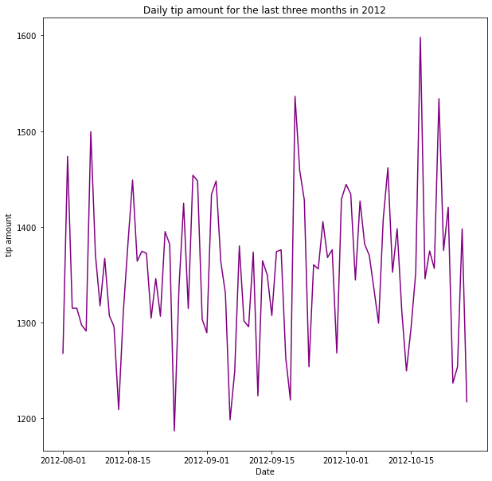

```python
fig, ax = plt.subplots(figsize=(10, 10))

# Add x-axis and y-axis
ax.plot(L3MON_daily.index.values,
           L3MON_daily['tip_amount'],
           color='purple')

# Set title and labels for axes
ax.set(xlabel="Date",
       ylabel="tip amount",
       title="Daily tip amount for the last three months in 2012")
```